# IE360 Final RMD

# Introduction

In this work, market clearing price of related currency will be forecasted by the methods of regression and time series analysis. Then, forecasts will be evaluated in terms of accuracy.

# Step 1

In this step, necessary libraries are obtained and data table is created. Useful method to compute accuracy is also created.

```r
library(data.table)
library(ggplot2)
library(dplyr)
require(mgcv)
library(fpp)
require(gratia)
library(readxl)
library(lubridate)
library(forecast)
library(zoo)
library(stringr)
library(stats)
library(urca)
setwd("/Users/mfdevecii/Desktop")
getwd()
```

```
## [1] "C:/Users/mfdevecii/Desktop"
```

```r
data=data.table(read.csv("mcp_with_variables.csv"))

accu=function(actual,forecast){
  n=length(actual)
  error=actual-forecast
  mean=mean(actual)
  sd=sd(actual)
  CV=sd/mean
  MAPE=sum(abs(error/actual))/n
  l=data.frame(MAPE)
  return(l)
}
```

# Step 2

In this step, classes of columns are checked, some of time series are created and preliminary visiulation of data is conducted to see how to proceed. Time series frequency of mcp currencies are selected as 24 to make easier analysis. Furthermore, one of the currencies will be chosen in this step to proceed with. Lastly, autocorrelations of MCP’s will be examined.

## Class Check and TS Creation Part

```r
class(data$date)
```

```
## [1] "factor"
```

```r
class(data$hour)
```

```
## [1] "integer"
```

```r
class(data$mcp_try)
```

```
## [1] "numeric"
```

```r
class(data$mcp_dollars)
```

```
## [1] "numeric"
```

```r
class(data$load_plan)
```

```
## [1] "integer"
```

```r
class(data$total_prod)
```

```
## [1] "numeric"
```

```r
class(data$natural_gas)
```

```
## [1] "numeric"
```

```r
class(data$other)
```

```
## [1] "numeric"
```

```r
try=ts(data$mcp_try,frequency = 24)
dollar=ts(data$mcp_dollars,frequency = 24)
euro=ts(data$mcp_euro,frequency = 24)
```

## mcp as try

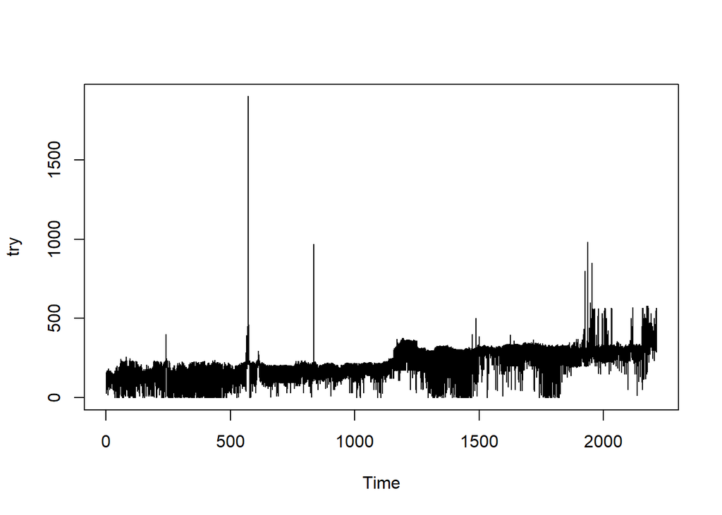

```r
plot(try)
```

```r
kpss.test(try,null="Trend")
```

```
##
##  KPSS Test for Trend Stationarity
##
## data:  try
## KPSS Trend = 2.9556, Truncation lag parameter = 19, p-value = 0.01
```

```r
kpss.test(try,null="Level")
```

```
##
##  KPSS Test for Level Stationarity
##
## data:  try
## KPSS Level = 174.22, Truncation lag parameter = 19, p-value = 0.01
```

```r
adf.test(try)
```

```
##
##  Augmented Dickey-Fuller Test
##
## data:  try
## Dickey-Fuller = -16.99, Lag order = 37, p-value = 0.01
## alternative hypothesis: stationary
```

Try plot has some outliers. Its graphic tells us data has little tendency to increase in time. But from kpss and adf tests it can be concluded that null hypothesis is rejected at alpha value of 0.05. This currency can be used in forecasts but as it is going to be seen in next step, dollar graph is more stable in terms of variance and mean.